# Statistical Rethinking Notes

2nd Edition

Callum Arnold

2021-05-25

This is a notebook that contains notes and code generated whilst going through Richard McElreath’s Statistical Rethinking book (2nd ed). Each chapter’s comments and answers to the questions will be copied and posted on my website.

> *NOTE:* At present the sub-subsection numbers are not correct as I am not including every sub-subsection. The section and subsection numbers should correspond to the correct values in the book

# 1 The Golem of Prague

Chapter one primarily summarizes the motivations behind the book, and a shift away from traditional frequentist statistical analysis that aim to falsify a null hypothesis using a statistical model selected from a flowchart, to a Bayesian framework that focuses on model comparison and evaluation, multilevel models as the norm, and evaluating the different process models that may link your statistical model to your hypotheses.

# 2 Small Worlds and Large World

- Can think of models as small worlds vs large worlds:
  - They are at best a small version of reality
  - Often they fail to test/be able to test for a number of errors and possibilities
  - Should always seek to ensure the model performs under favourable assumptions
- Bayesian models are well suited as they are designed to account for this
  - Particularly when frequently tested against reality and updated

## 2.1 The garden of forking data

- Bayesian inferece is primarily just counting and comparing possibilities
  - All possible outcomes (conjectures) are considered, and options “pruned” as more data is considered that do not provide evidence for these outcomes
- Example:
  - Count all the ways the observed data can be observed for each conjecture
  - Consider the relative plausibilities of each conjecture
    - Take counts from the first round, and instead of starting again, use as your *prior* for each additional data point
      - Count the number of ways each conjecture can produce the individual data point, and multiply this value by the *prior* count
      - Requires that new data is logically independent of previous, otherwise recalculate from the start
      - Doesn’t require new data to be the same type
    - Convert to probabilities
      - Counts become harder to manage as they increase and we’re only interested in the relative size of the counts
- Important components of Bayesian formula:
  - Parameter value
    - Conjectured proportion
  - Likelihood
    - Relative number of ways the parameter value can produce the data
  - Prior probability
    - Initial probability of seeing the parameter value
  - Posterior probability
    - Probability of seeing the parameter value after accounting for the new data

## 2.2 Building a model

- Basic process of Bayesian modelling
  1. Determine possible ways data can be observed
  - Often need to describe underlying reality as well as sampling process
  - Be specific with story and resolve ambiguities
  2. Update model by adding data
  - Plausibility of each value of *p*, the estimate of the true value of the parameter, is updated as more data is added
  - Because it it iterative, you can calculate the distributions both forwards and backwards given all the data points
  - Means that no minimum sample size is required to be valid (just the inferences will be less clear as wider distribution), but small sample sizes are sensitive to priors
  3. Evaluate model and revise
  - Inferences are conditional to the model, so may be incredibly confident in model A, but very different with a different model
  - Need to consider the model assumptions, e.g. order of data doesn’t matter, so that we can consider validity of the model’s inferences (which aren’t affected by data it doesn’t consider)
  - These checks confirm the model’s adequacy for a specific purpose

## 2.3 Components of the model

- Need to explicitly name the variables and provide definitions
- Variables
  - First variable is target of interest (often a proportion)
  - Unobserved variables often called parameters
  - Observed variables are the data
- Definitions
  - Build a model that relates a variable to the others
  - For each parameter, define the probability of seeing each observed variable values (data point)
    - Then, for each parameter, define the prior plausibility of each of these values
      - Each specific value of *p* corresponds to a specific plausibility of the data
      - We define the plausibility with a distribution (sometimes called the likelihood, but not technically correct in a Bayesian sense)
      - When there are only 2 possible outcomes, we use the binomial distribution
      - For 6 successes in 9 bernoulli trials with prior plausibility 0.5 (*p*), the plausibility = 0.1640625
    - Each parameter must have a prior plausibility
      - This becomes a *prior* when you have previous estimates
      - Can specify and test multiple priors, like with other model components
  - Binomial distribution example
    - $W \sim \text{Binomial}(N, p): \text{with } p \sim \text{Uniform}(0, 1)$
      - Uniform (flat) prior plausibility

## 2.4 Making the model go

- Model outputs that posterior distribution that is the probability of the parameters conditional on the data (and the model)
- The joint probability of the data $W$ and $L$ with probability $p$ is:

$$\begin{aligned}
\text{Pr}(W, L, p) &= \text{Pr}(W, L \mid p) \times \text{Pr}(p) \\
&= \text{Pr}(p \mid W, L) \times \text{Pr}(W, L) \\
&\therefore \\
\text{Pr}(p \mid W, L) \times \text{Pr}(W, L) &= \text{Pr}(W, L \mid p) \times \text{Pr}(p) \\
\text{Pr}(p \mid W, L) &= \frac{\text{Pr}(W, L \mid p) \times \text{Pr}(p)}{\text{Pr}(W, L)}
\end{aligned}$$

- Here $\text{Pr}(W, L)$ is the *average* probability of data (over the prior)
  - AKA the *marginal likelihood*

$$\begin{aligned}
\text{Pr}(W, L) &= \text{E}\left(\text{Pr}(W, L \mid p)\right) \\
&= \int \text{Pr}(W, L \mid p) \times \text{Pr}(p) dp
\end{aligned}$$

- Most importantly $\text{Pr}(W, L \mid p) \propto \text{Pr}(W, L \mid p) \times \text{Pr}(p)$
- Often it is not possible to *condition* the prior on the data, so much use numerical approximations each with different limitations and assumptions
  - Grid approximation
  - Quadratic approximation
  - Markov Chain Monte-Carlo (MCMC)

### 2.4.1 Grid approximation

- Converts continuous parameters to finite grids of values
- Limitations
  - Doesn’t scale well with increasing number of parameters

Let’s have a look at the binomial example used in the book. Here I turn it into a function so I can try different priors easily (shown in the book).

```r
p_grid <- seq(0, 1, 0.05)

grid_approx <- function(prior){
  # Calculation
  likelihood <- dbinom(6, 9, p_grid)
  unstd_post <- likelihood * prior
  post <- unstd_post / sum(unstd_post)

  # Plotting
  plot <- plot(p_grid, post, type = "b")
}
```

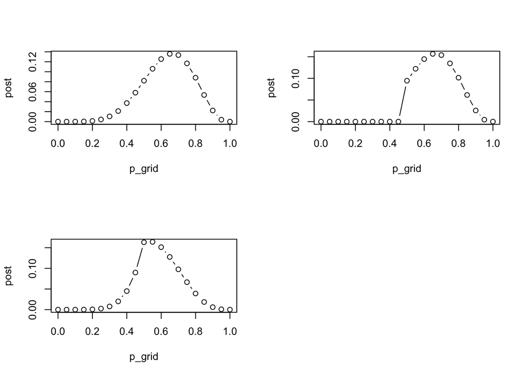

```r
par(mfrow = c(2, 2))
grid_approx(prior = rep(1, 20))
grid_approx(prior = ifelse(p_grid < 0.5, 0, 1))
grid_approx(prior = exp(-5 * abs(p_grid - 0.5)))
```

### 2.4.2 Quadratic approximation

- Assumption that the peak of the posterior distribution can be approximated by a Guassian distribution
  - First find peak using some optimization algorithm (often based on calculating Hessians - the 2nd derivate of the parabola - which is proportional to its std)
  - The log of the Guassian (posterior) is a parabola (i.e. quadratic function)
  - In some instances, is exactly correct
- Computationally inexpensive relative to grid approximation and MCMC
- Limitations
  - Only accurate approximation near the peak of the posterior
  - Relies on decent sample size

We’ll use the `quap()` function in the `{rethinking}` package to demonstrate a binomial example. As in the book, the blue curve is the posterior distribution calculated numerically using the beta distribution, and the black line is the quadratic approximation. The key insight is that increasing the amount of data increases the accuracy of the approximation. This is why frequentist statistics heavily relies on sample size, as the quadratic approximation is involved. However, just because it improves with *n*, doesn’t mean high *n* = good model.

> *NOTE:* The Beta distribution is a probability distribution of probabilities with $\text{Beta}(\alpha, \beta) \text{ where: } \mu = \frac{\alpha}{\alpha \beta}$ see [this answer](https://stats.stackexchange.com/questions/47771/what-is-the-intuition-behind-beta-distribution)

```r
library(rethinking)

quad_approx <- function(W, L){
  globe_qa <- quap(
    alist(
      W ~ dbinom(W+L, prob = p),
      p ~ dunif(0, 1)
    ),
    data = list(W = W, L = L)
  )

  mean <- precis(globe_qa)$mean
  sd <- precis(globe_qa)$sd

  curve(dbeta(x, W + 1, L + 1), from = 0, to = 1, col = "blue")
  curve(dnorm(x, mean, sd), add = TRUE)
  mtext(text = glue::glue("n = {W + L}"))
}
```

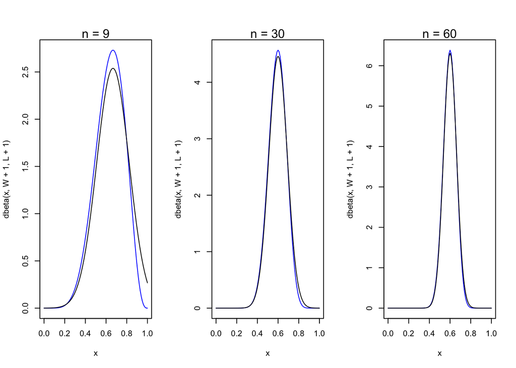

```r
par(mfrow = c(1, 3))
quad_approx(W = 6, L = 3)
quad_approx(W = 18, L = 12)
quad_approx(W = 36, L = 24)
```

### 2.4.3 Markov Chain Monte-Carlo

- Useful for multilevel models where posterior can’t be expressed in one equation simply
- Draws samples from posterior distribution and uses relative frequencies of parameter values as plausibility
  - Don’t directly compute or approximate the posterior distribution

## 2.5 Practice

### 2.5.1 E1

2 ($\text{Pr}(\text{rain} | \text{Monday})$) and 4 ($\text{Pr}(\text{rain, Monday}) / \text{Pr}(\text{Monday})$)

### 2.5.2 E2

3 (The probability that it’s Monday, given it’s raining)

### 2.5.3 E3

1 ($\text{Pr}(\text{Monday} | \text{rain})$) and 4 $\left(\frac{\text{Pr}(\text{rain} | \text{Monday}) \text{Pr}(\text{Monday})}{\text{Pr}(\text{rain})}\right)$

> *NOTE:* The numerator is the joint probability of it raining and being Monday, so we divide by the probability of it raining to get the probability of it being Monday conditioned on it raining

### 2.5.4 E4

This statement implies that we are uncertain each time we toss the globe whether we’ll land on land or water, but on average, we are assuming that we will land on water 70% of the time (as it covers 70% of the surface and we’re assuming an unbiased globe so each point it equally likely to be picked), and we have no knowledge that would allow us to predict exactly where it would land.

### 2.5.5 M1

```r
p_grid <- seq(0, 1, 0.01)

grid_approx <- function(prior, W, tot){
  # Calculation
  likelihood <- dbinom(W, tot, p_grid)
  unstd_post <- likelihood * prior
  post <- unstd_post / sum(unstd_post)

  # Plotting
  plot <- plot(p_grid, post, type = "l")
  mtext(text = glue::glue("{W} W / {tot} total"))
}
```

- In clockwise plot order with a uniform prior
  - W W W
  - W W W L
  - L W W L W W W

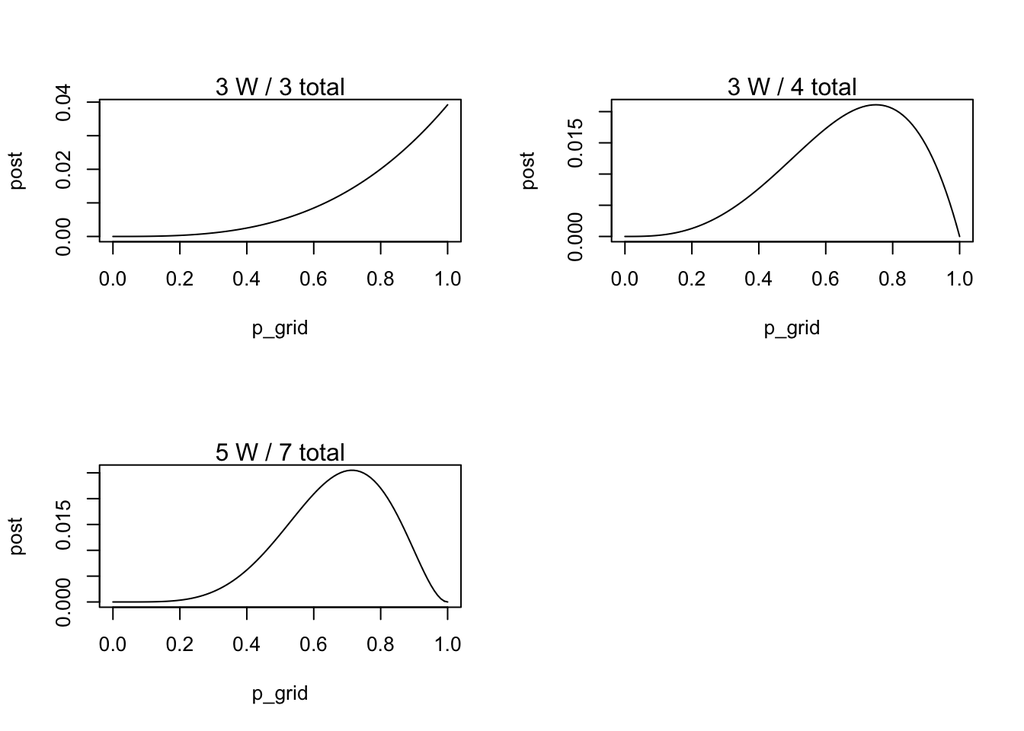

```r
par(mfrow = c(2, 2))
grid_approx(prior = rep(1, 100), W = 3, tot = 3)
grid_approx(prior = rep(1, 100), W = 3, tot = 4)
grid_approx(prior = rep(1, 100), W = 5, tot = 7)
```

### 2.5.6 M2

- In clockwise plot order with a step prior
  - W W W
  - W W W L
  - L W W L W W W

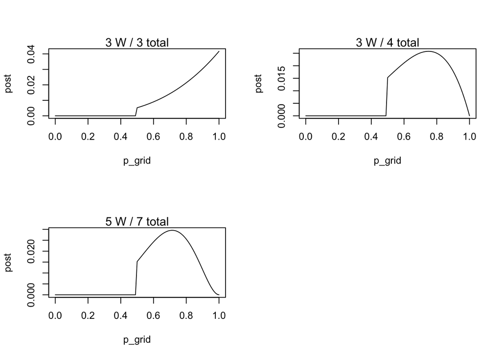

```r
par(mfrow = c(2, 2))
grid_approx(prior = ifelse(p_grid < 0.5, 0, 1), W = 3, tot = 3)
grid_approx(prior = ifelse(p_grid < 0.5, 0, 1), W = 3, tot = 4)
grid_approx(prior = ifelse(p_grid < 0.5, 0, 1), W = 5, tot = 7)
```

### 2.5.7 M3

$$\begin{aligned}
\text{Pr}(\text{Earth} | \text{Land}) &= \frac{\text{Pr}(\text{Land} | \text{Earth}) \text{Pr}(\text{Earth})}{\text{Pr}(\text{Land})} \\
&= \frac{0.3 \times 0.5}{(1 + 0.3) / (1 + 1)} \\
&\approx 0.23
\end{aligned}$$

### 2.5.8 M4

The B/B card has 2 ways of producing a B side up, the B/W card has 1 way of producing B side up, and the W/W card has 0 ways. Therefore the probability of the other side being B is 2 / (2 + 1)

### 2.5.9 M5

There are 2 ways of approaching this problem: 1st, repeat the method above, and 2nd, update our answer from above.

1. we end up with 4 ways of picking B from B/B and 1 way from B/W, so p = 0.8
2. The prior odds are 2:1, which we multiply by 2 (the number of ways of picking B with our new card) resulting in a posterior odds of 4:1, which converted to a probability is p = 0.8

### 2.5.10 M6

There are 2 ways of picking B from the B/B card, and 1 way from B/W, as in M4. However, the relative frequencies are 1 and 2, respectively. Multiplying the number of ways of selecting B from each card by its frequency we get a posterior odds of 2:2, i.e. p = 0.5

### 2.5.11 M7

Starting with the first card:

- There are 2 ways to see B from B/B
  - There is 1 way to see W from B/W and 2 ways from W/W (the remaining cards)
  - Multiplying the ways: $2 \times (1 + 2) = 6$
- There is 1 way to see B from B/W
  - There are 2 ways to see W from W/W and 0 from B/B (the remaining cards)
  - Multiplying the ways: $1 \times (2 + 0) = 2$
- In 6 of the 8 ways of getting B then W, the first card is B/B, so p = 0.75

### 2.5.12 H1

### 2.5.13 H2

### 2.5.14 H3

### 2.5.15 H4

# 3 Sampling the Imaginary

- Frequencies are often more intuitive than probabilities
  - Think of Bayes rule for PPV of a test
- Can sample the posterior probability distribution to produce frequencies for the parameter values
  - More intuitive for many scientists than integrating the distribution
  - MCMC techniques rely on samples of the posterior distribution
- Assuming random sampling, the relative frequencies of the parameter values samples from the posterior should be proportionate to their relative probabilities

Let’s quickly show it in practice to estimate the posterior probability of landing on water in our globe tossing example, created using the grid approximation method from earlier

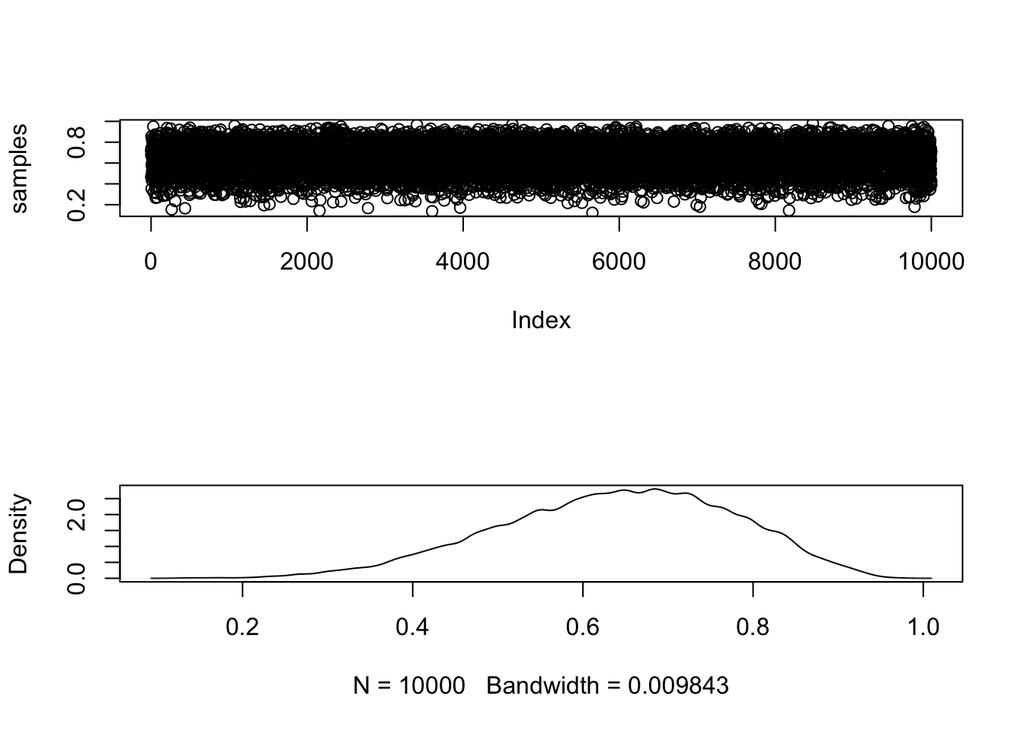

```r
p_grid <- seq(0, 1, length.out = 1000)
likelihood <- dbinom(6, 9, p_grid)
unstd_post <- likelihood * rep(1, 1000)
post <- unstd_post / sum(unstd_post)

samples <- sample(p_grid, prob = post, size = 10000, replace = TRUE)
par(mfrow = c(2, 1))
plot(samples)
dens(samples)
```

## 3.1 Sampling to summarize

### 3.1.1 An interval

To find the probability contained within an interval i.e., the integral between two boundaries, we just sum the frequencies and divide by the total number of samples taken!

```r
sum(samples > 0.5 & samples < 0.75) / 1e4
```

```
## [1] 0.6079
```

### 3.1.2 Intervals of defined mass

To calculate the “Credible Interval” (“comptability interval”), there are two methods: - Percentile intervals (“equal tails”) - Good when not too asymmetrical - Highest posterior density intervals - The narrowest interval containing a specified probability mass - More representative of the data - More computationally intensive than PIs - Greater simulation variance i.e., sensitive to number of samples drawn

The `{rethinking}` package has functions to calculate both

```r
PI(samples, prob = 0.90)
```

```
##        5%       95%
## 0.3953954 0.8468969
```

```r
HPDI(samples, prob = 0.9)
```

```
##      |0.9      0.9|
## 0.4154154 0.8618619
```

### 3.1.3 Point estimate

Can report:

- Mode (maximum a posteriori - MAP)
  - The `chainmode` function from `{rethinking}` useful for computing the mode of posterior samples, and should be similar to the max value of the posterior

```r
p_grid[which.max(post)]
```

```
## [1] 0.6666667
```

```r
chainmode(samples, adj = 0.01)
```

```
## [1] 0.6813358
```

- Median
- Mean

Different loss functions will prefer different point estimate measures - Absolute loss -> median - Quadratic loss -> mean

## 3.2 Sampling to simulate prediction

### 3.2.1 Dummy Data

- Can sample the prior to understand the model assumptions

For the globe tossing example, we have a binomial distribution and can sample directly from it e.g.,

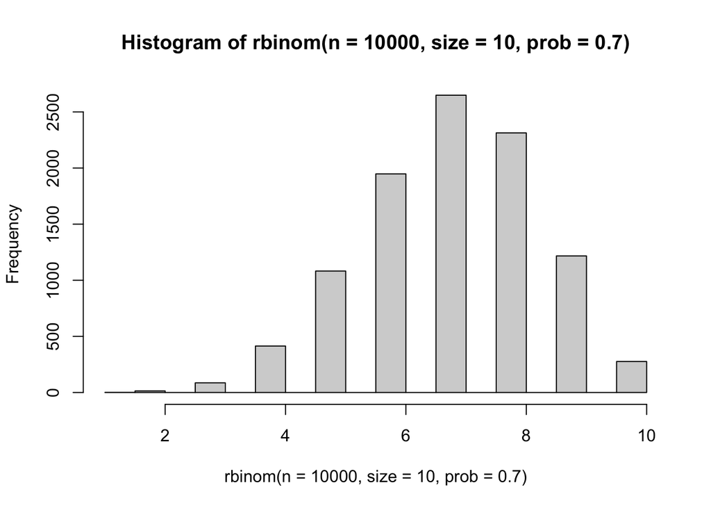

```r
hist(rbinom(n = 1e4, size = 10, prob = 0.7))
```

### 3.2.2 Model checking

#### 3.2.2.1 Software works

- Retrodiction
  - Can the model reproduce the data that created it i.e. predict the training data
  - Useful to help check the code itself is working as expected, therefore producing the “correct” posterior for the model assumptions

#### 3.2.2.2 Adequate model

- Want to explain how the model’s assumptions fails
- Want to combine sampling of simulated observations with sampling parameters from posterior distribution
  - Want to use the entire posterior, not just point estimate, otherwise lose uncertainty and results in overconfidence
    - Observation uncertainty - model can’t be certain about the next value
    - Parameter uncertainty - uncertainty around *p*, the parameter value
- To propagate the parameter uncertainty, we average all outcome prediction distributions (calculated by sampling all parameter values) weighted by the posterior probability of the parameter values, to create the posterior predictive distribution
  - I.e., more likely parameter values contribute more to the final weight average frequency of each possible observation
- Below is a histogram of this posterior prediction distribution of counts of landing on water, for all parameter values (*p* = probability of landing on water), which we can see is relatively similar to our example above, except it is less confident than when we only use the peak of the posterior probability distribution (*p = 0.7*)

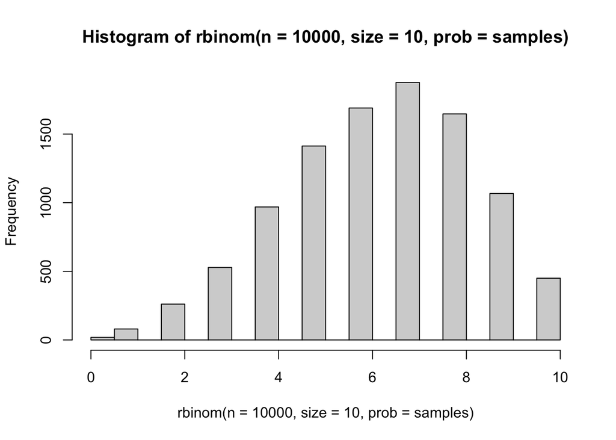

```r
hist(rbinom(n = 1e4, size = 10, prob = samples))
```

- Need to think about core assumptions and appropriateness of them i.e., our model assumes that each toss is independent of the others - this may not be the case so our model could be *mis-specified*
  - Will the model eventually converge on the correct distribution?

## 3.3 Practice

### 3.3.1 E1

```r
p_grid <- seq( from=0 , to=1 , length.out=1000 )
prior <- rep( 1 , 1000 )
likelihood <- dbinom( 6 , size=9 , prob=p_grid )
posterior <- likelihood * prior
posterior <- posterior / sum(posterior)
RNGkind(sample.kind = "Rounding") # This is required for >= R v3.6
set.seed(100)
samples <- sample( p_grid , prob=posterior , size=1e4 , replace=TRUE )
```

```r
sum(samples < 0.2) / 1e4
```

```
## [1] 5e-04
```

### 3.3.2 E2

```r
sum(samples > 0.8) / 1e4
```

```
## [1] 0.1117
```

### 3.3.3 E3

```r
sum(samples > 0.2 & samples < 0.8) / 1e4
```

```
## [1] 0.8878
```

### 3.3.4 E4

```r
PI(samples, prob = 0.6)
```

```
##       20%       80%
## 0.5195195 0.7567568
```

### 3.3.5 E5

```r
PI(samples, prob = 0.6)
```

```
##       20%       80%
## 0.5195195 0.7567568
```

### 3.3.6 E6

```r
HPDI(samples, prob = 0.66)
```

```
##     |0.66     0.66|
## 0.5205205 0.7847848
```

### 3.3.7 E7

```r
PI(samples, prob = 0.66)
```

```
##       17%       83%
## 0.5005005 0.7687688
```

### 3.3.8 M1

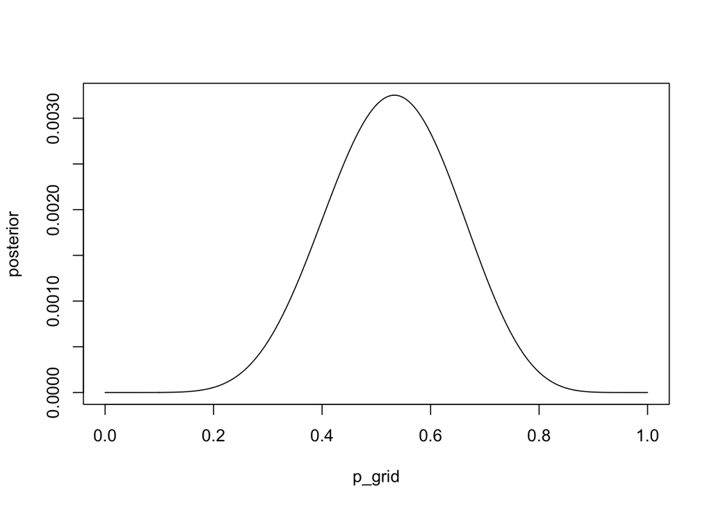

```r
likelihood <- dbinom(x = 8, size = 15, prob = p_grid)
unstd_post <- likelihood * prior
posterior <- unstd_post / sum(unstd_post)

plot(posterior ~ p_grid, type = "l")
```

### 3.3.9 M2

```r
samples <- sample(x = p_grid, prob = posterior, size = 1e4, replace = TRUE)
HPDI(samples, prob = 0.9)
```

```
##      |0.9      0.9|
## 0.3383383 0.7317317
```

### 3.3.10 M3

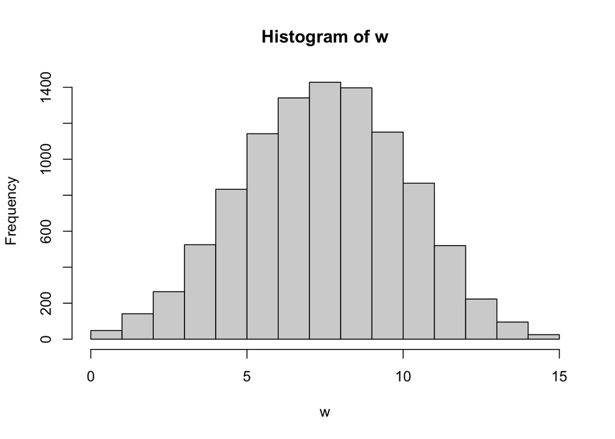

```r
w <- rbinom(n = 1e4, size = 15, prob = samples)
hist(w)
```

```r
sum(w == 8) / 1e4
```

```
## [1] 0.1428
```

### 3.3.11 M4

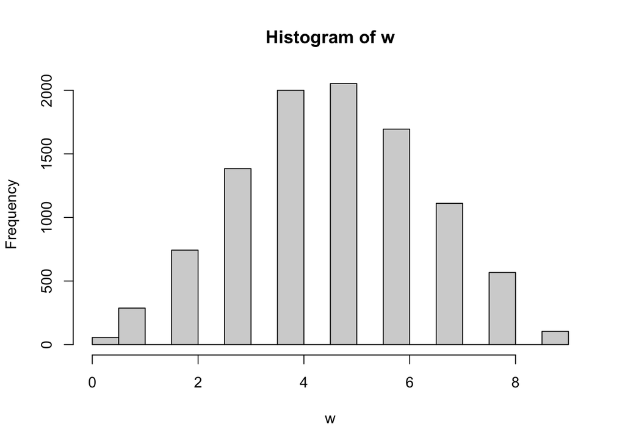

```r
w <- rbinom(n = 1e4, size = 9, prob = samples)
hist(w)
```

```r
sum(w == 6)/1e4
```

```
## [1] 0.1695
```

### 3.3.12 M5

```r
p_grid <- seq( from=0 , to=1 , length.out=1000 )
prior <- ifelse(p_grid < 0.5, 0, 1)
likelihood <- dbinom(x = 8, size = 15, prob = p_grid)
unstd_post <- likelihood * prior
posterior <- unstd_post / sum(unstd_post)
RNGkind(sample.kind = "Rounding") # This is required for >= R v3.6
set.seed(100)
samples <- sample( p_grid , prob=posterior , size=1e4 , replace=TRUE )
```

#### 3.3.12.1 M1

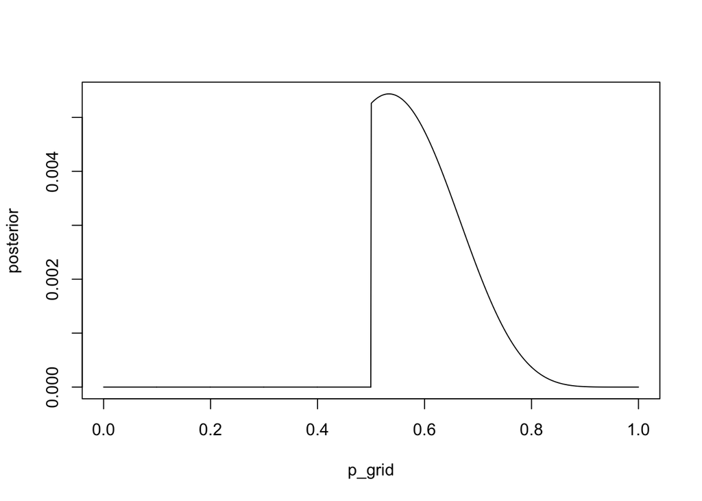

```r
plot(posterior ~ p_grid, type = "l")
```

#### 3.3.12.2 M2

```r
samples <- sample(x = p_grid, prob = posterior, size = 1e4, replace = TRUE)
HPDI(samples, prob = 0.9)
```

```
##      |0.9      0.9|
## 0.5005005 0.7137137
```

Much narrower CrIs

#### 3.3.12.3 M3

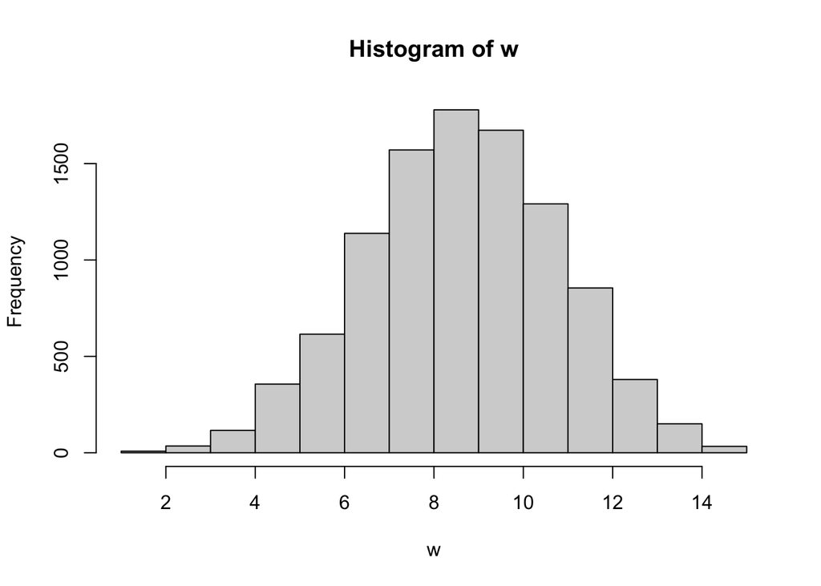

```r
w <- rbinom(n = 1e4, size = 15, prob = samples)
hist(w)
```

```r
sum(w == 8) / 1e4
```

```
## [1] 0.1571
```

No longer centered on 8 (the number in the original data that we used to create the posterior distribution from)

#### 3.3.12.4 M4

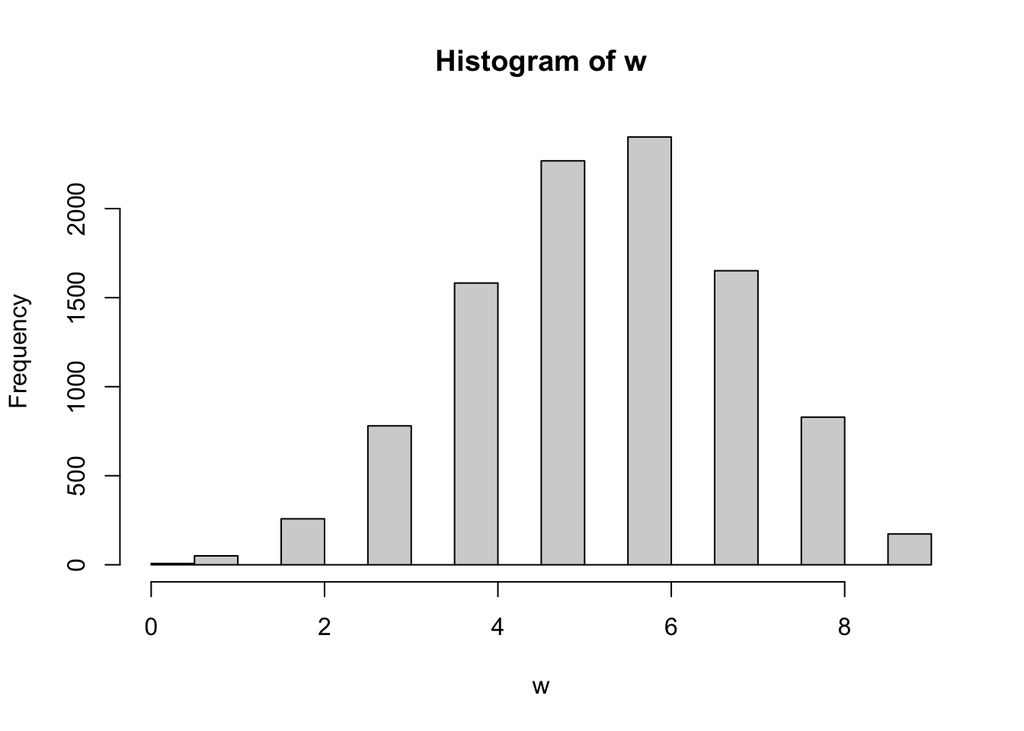

```r
w <- rbinom(n = 1e4, size = 9, prob = samples)
hist(w)
```

```r
sum(w == 6)/1e4
```

```
## [1] 0.2402
```

### 3.3.13 H1

```r
data(homeworkch3)
```

```r
boys <- sum(birth1 + birth2)
girls <- 200 - boys
```

```r
p_grid <- seq( from=0 , to=1 , length.out=1000 )
prior <- rep(1, 1000)
likelihood <- dbinom(x = boys, size = 200, prob = p_grid)
unstd_post <- likelihood * prior
posterior <- unstd_post / sum(unstd_post)
```

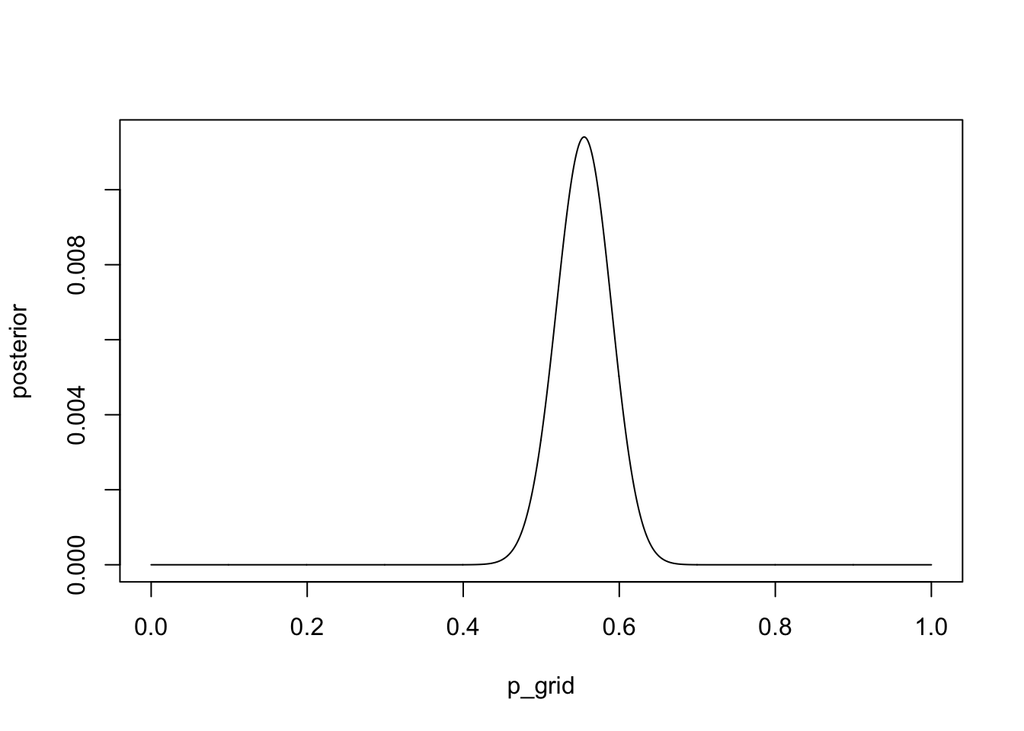

```r
plot(posterior ~ p_grid, type = "l")
```

```r
p_grid[which.max(posterior)]
```

```
## [1] 0.5545546
```

### 3.3.14 H2

```r
RNGkind(sample.kind = "Rounding") # This is required for >= R v3.6
set.seed(100)
samples <- sample( p_grid , prob=posterior , size=1e4 , replace=TRUE )
```

```r
hdpis <- c(0.5, 0.89, 0.97)

purrr::map(hdpis, .f = ~HPDI(samples, prob = .x))
```

```
## [[1]]
##      |0.5      0.5|
## 0.5315315 0.5765766
##
## [[2]]
##     |0.89     0.89|
## 0.4974975 0.6076076
##
## [[3]]
##     |0.97     0.97|
## 0.4774775 0.6276276
```

### 3.3.15 H3

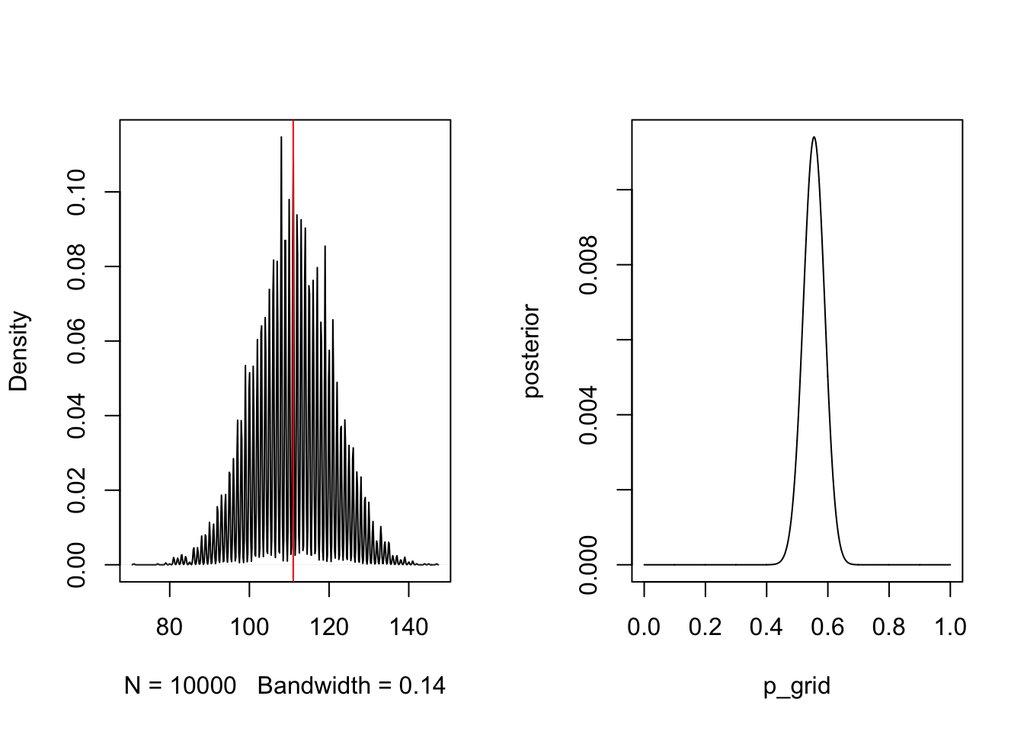

```r
boys_pred <- rbinom(1e4, size = 200, prob = samples)
par(mfrow = c(1, 2))
dens(boys_pred, adj = 0.1)
abline(v = boys, col = "red")
plot(posterior ~ p_grid, type = "l")
```

### 3.3.16 H4

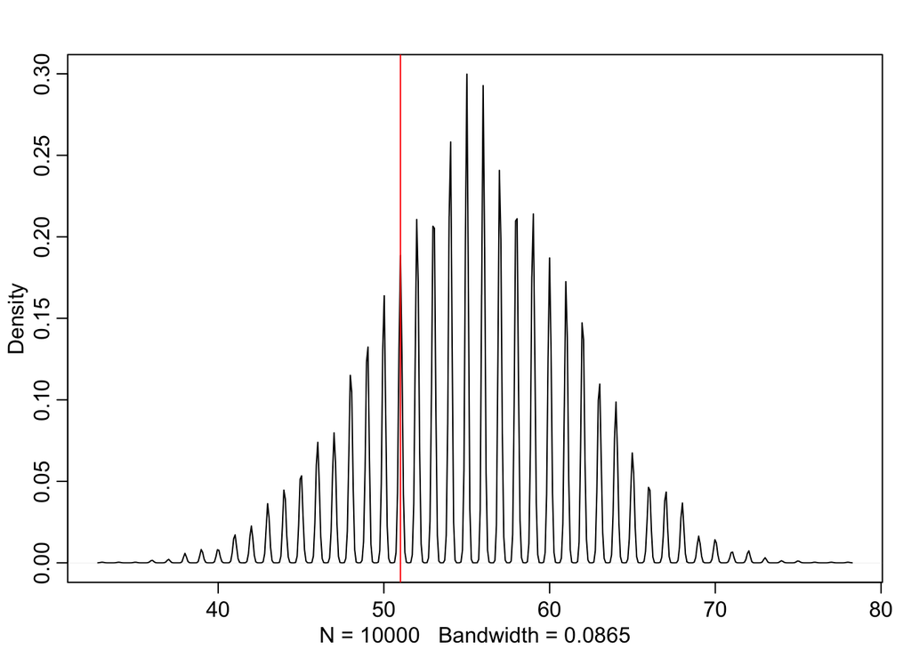

```r
first_boy <- rbinom(1e4, size = 100, prob = samples)
dens(first_boy, adj = 0.1)
abline(v = sum(birth1), col = "red")
```

### 3.3.17 H5

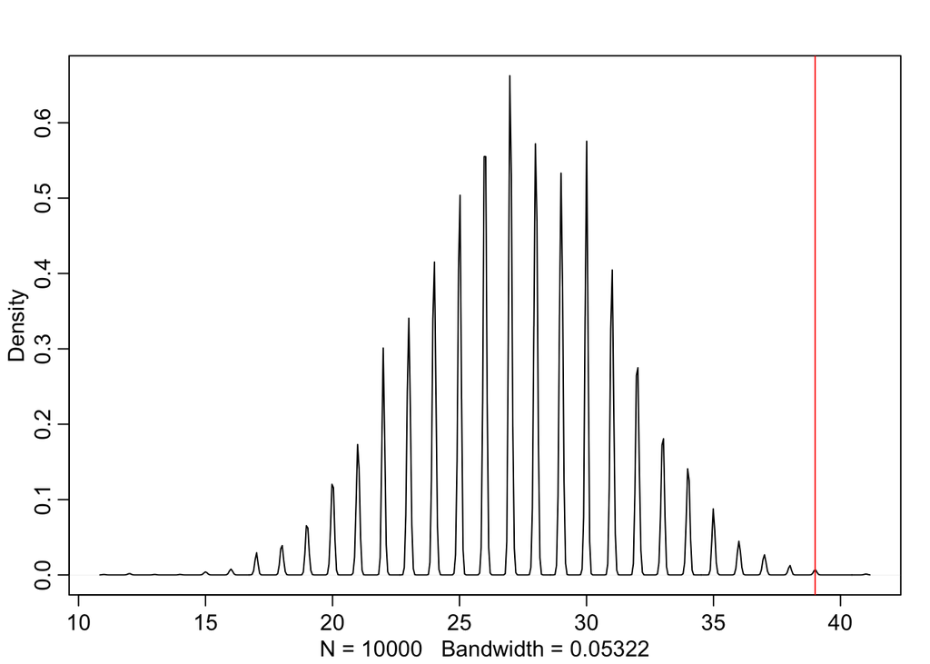

```r
first_girl <- birth2[birth1 == 0]
sec_boy_sim <- rbinom(1e4, size = length(first_girl), prob = samples)
dens(sec_boy_sim, adj = 0.1)
abline(v = sum(first_girl), col = "red")
```

# 4 Geocentric Models

## 4.1 Normal by addition

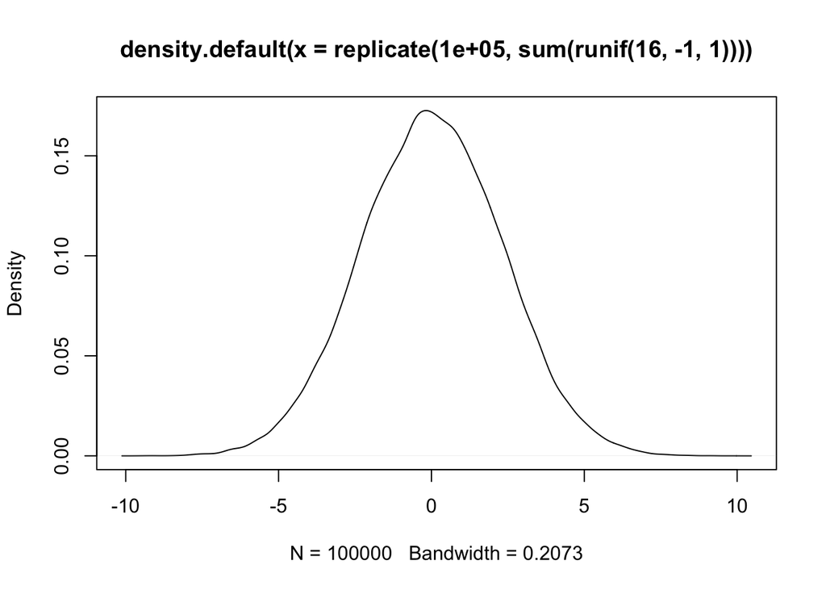

```r
plot(density(replicate(1e5, sum(runif(16, -1, 1)))))
```

- Can think of it as most fluctuations from the average (0 = starting point) cancel each other out, and more ways to cancel out than to end up further away from 0

### 4.1.1 Normal by multiplication

- Multiplying small number approx. additive

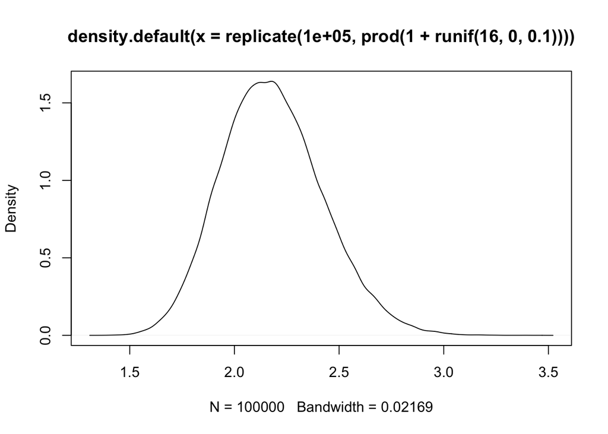

```r
plot(density(replicate(1e5, prod(1 + runif(16, 0, 0.1)))))
```

### 4.1.2 Normal by log-multiplication

- Large deviations multiplied produce Gaussian distributions on the log scale

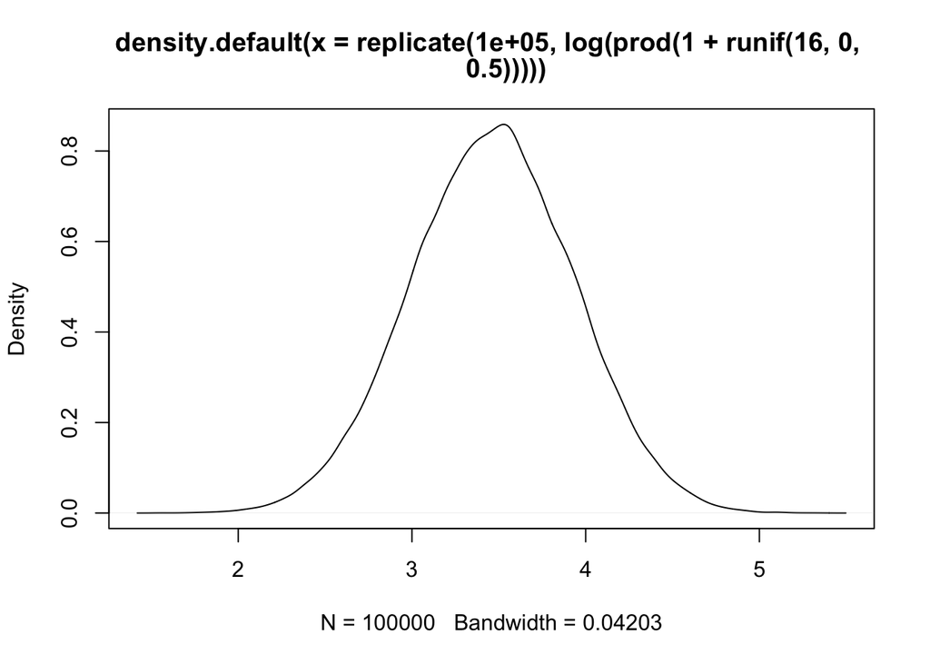

```r
plot(density(replicate(1e5, log(prod(1 + runif(16, 0, 0.5))))))
```

### 4.1.3 Using Gaussian distributions

- Reasons for using Gaussian:
  - Ontological:
    - Many processes approximate Gaussian
  - Epistemological:
    - Most consistent with our assumptions when all we know is mean and variance
      - Doesn’t introduce new assumptions above “each measure has a finite variance”
    - Premised on **Information Theory** and **Maximum Entropy**
- Reasons not to:
  - Gaussian distributions have thin tails
    - Many long-running time series (and other processes) have fat tails e.g., long term stock markets

## 4.2 A language for describing models

1. Identify **variables**
   1. Observable = *data*
   2. Unobservable = *parameters*
2. Define variables in terms of other variables or a probability distribution
3. Combination of variables and their probability distributions defines a **joint generative model**
   1. Used to simulate both hypothetical and real observations

### 4.2.1 Re-describing the globe tossing model

$$\begin{aligned}
W &\sim \text{Binomial}(N, p) \\
p &\sim \text{Uniform}(0, 1)
\end{aligned}$$

This can be read as:

- The count $W$ is distributed binomially with sample size $N$ and probability $p$
  - This defines the likelihood function in Bayes’ theorem

  $$\begin{aligned}
  \text{Pr}(p \mid w, n) = \frac{\text{Binomial}(w \mid n, p) \text{Uniform}(p \mid 0, 1)}{\int \text{Binomial}(w \mid n, p) \text{Uniform}(p \mid 0, 1) dp}
  \end{aligned}$$
- The prior for $p$ is assumed to be uniform between 0 and 1
- The symbol $\sim$ indicates that it is **stochastic**
  - A mapping of a variable or parameter onto a distribution
  - No single instance of the variable on the left is known with certainty (mapping is probabilistic)